# الأمية في مصر- بمناسبة اليوم الدولي لمحو الأمية 2018

Ayman Amin

2018-09-09

بالأمس تم الاحتفال [باليوم الدولي لمحو الأمية](https://ar.unesco.org/themes/literacy-all/literacy-day) ، في كثير من الدول التي أحدثت تقدماً في القضاء علي الأمية. بدايةً بدون تعقيدات يمكن تعريف الأمية علي أنها **عدم القدرة علي القراءة والكتابة** - وهو التعريف الأولي الذي تبنته اليونيسكو ولكنها طورت هذا التعريف كثيراً ليواكب ما نحن فيه من تقدم. هذا الاحتفال شد إنتباهي إلي إلقاء نظرة علي نتائج تعداد السكان في مصر لعام 2017 للتعرف علي الوضع الحالي للأمية في مصر إجمالا، وبتفصيلاتها المختلفة في الحضر مقارنة بالريف، وبين الذكور مقارنة بالإناث، وفي محافظات الجمهورية المختلفة. فعندما تصفحت تقارير [الجهاز المركزي للتعبئة العامة والإحصاء](https://capmas.gov.eg) الخاصة بتعداد السكان 2017، فوجدت أن نسبة الأمية بين المصريين (10 سنوات فأكثر) بلغت 25.8% علي مستوي الجمهورية ككل. أي أن أكثر من ربع المصريين (10 سنوات فأكثر) لا يجيدون القراءة والكتابة، أكثر من ربع المصريين لا يستطيعون بأنفسهم قراءة صلاحية الأغذية التي يتناولونها، أكثر من ربع المصريين لا يستطيعون التأكد من صحة الأدوية التي يتعالجون بها، أكثر من ربع المصريين لا يستطيعون قراءة كتاب عن التربية لتربية أولادهم، أكثر من ربع المصريين لا يستطيعون ….. (عدد ما تشاء من العقبات الحقيقية التي تعوق تنمية أي أمة بسبب الأمية). الأمية في الريف أكثر بكثير عنها في الحضر، فتشير نتائج تعداد السكان 2017 ان نسبة الأمية في الريف بلغت 32.2% مقارنةً ب 17.7% في الحضر – قرابة الضعف. كذلك الأمية بين الإناث أكثر بكثير عنها بين الذكور، فتشير نفس النتائج ان نسبة الأمية بين الإناث بلغت 30.8% مقارنةً ب 21.2% بين الذكور.

فالآن تبادر إلي ذهني سؤال بديهي: ما هو دور المؤسسات الحكومية – متمثلة في وزارة التربية والتعليم – والمجتمعات المدينة في مواجهة الأمية التي تعد أهم معوقات التنمية في مصر – من وجهة نظر الكثيرين – وهي الوجه الأخر للتخلف. هذا التساؤل دفعني للعودة بالزمن إلي أكثر من 10 سنوات – تحديدا عام 2006 – ومقارنة مستوي الأمية وقتها بما نحن فيه الآن، وما التطور الذي حدث. نتائج تعداد السكان 2006 أشارت إلي أن نسبة الأمية بين المصريين (10 سنوات فأكثر) كانت 29.7% في عام 2006، وبمقارنة هذه النسبة مع النسبة الحالية 25.8% (من تعداد السكان 2017) يبدو من النظرة الأولي إنخفاض الأمية في مصر – وإن كان قليلاً. فهل هذا حقيقي أن الأمية إنخفضت في مصر؟ دعونا نفحص الأمية من خلال أعداد الأميين في مصر وليس من خلال مقياس النسب. فنجد أن عدد الأميين المصريين (10 سنوات فأكثر) كان تقريبا 17 مليون في عام 2006 مقارنةً ب18.5 مليون تقريبا في عام 2017. أي أن هناك أكثر من 1.5 مليون مصري من الأجيال الجديدة دخلوا دائرة الأمية، والحقيقة أقول أنه أكثر من ذلك بكثير لأنه بالتأكيد هناك أميون من عام 2006 قد تم محو أميتهم أو ماتوا ولم يعدوا ضمن الأميين في عام 2017. فمن تعداد السكان 2017 نجد أن أقل من 392 ألف مصري أمي تم محو أميتهم. ولنفترض جدلاً أن هذا التقدير صحيح أن 1.5 مليون مصري من الأجيال الجديدة دخلوا دائرة الأمية خلال العشر سنوات الأخيرة، فهذا وإن دل علي شئ فإنما يدل علي أن الأمية مستمرة في مصر- بل وقد تكون في تزايد – وأن اسباب تزايدها الحقيقية موجودة، والتي من أهمها التسرب من التعليم الذي تزايد في الفترة الأخير خاصة في الريف.

من المتوقع أن تختلف محافظات الجمهورية من حيث نصيبها من الأمية، ولتوضيح ذلك تم عرض نسب الأمية في المحافظات المختلفة من خلال الخريطة التالية

[figure not shown]

المجموعة الأولي ذات مستويات عالية للأمية (أعلي من 30%) وهي تتضم أغلب محافظات الصعيد (تحديداً، سوهاج وأسيوط والمنيا وبني سويف والفيوم) وبعض محافظات وجه بحري (البحيرة ومطروح).

المجموعة الثانية ذات مستويات متوسطة للأمية (أعلي من 20% وأقل من 30%) وهي تتضم أغلب محافظات وجه بحري.

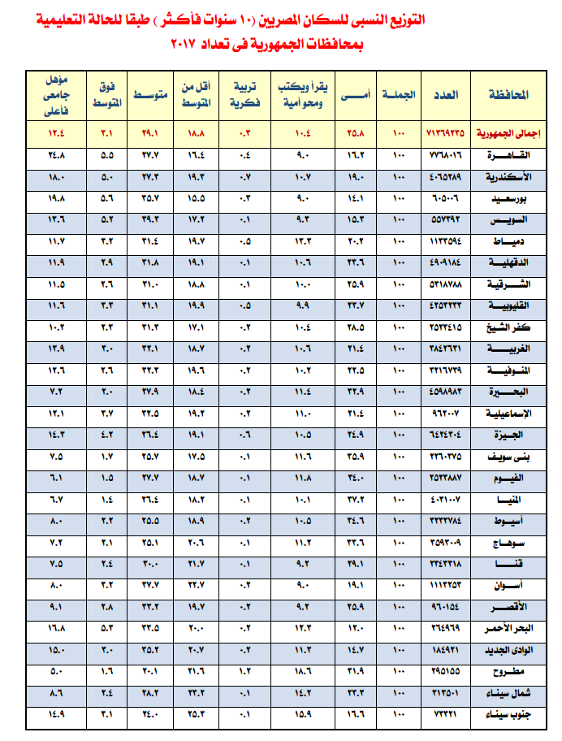

المصدر: تقرير [الجهاز المركزي للتعبئة العامة والإحصاء](https://capmas.gov.eg) الخاص بتعداد السكان 2017

تجدر الإشارة هنا إلي أن الهدف الرابع من أهداف التنمية المستدامة هو: **ضمان التعليم الجيد المنصف والشامل للجميع وتعزيز فرص التعلّم مدى الحياة للجميع**، لذلك بدون القضاء علي الأمية لن نتمكن من تحقيق أهداف التنمية المستدامة للتربية والتعليم.